# PRACTICE TOPIC - MATPLOTLIB FUNCTIONS WITH VISUALIZATION

```python
import matplotlib.pyplot as plt
```

```python
import numpy as np
```

# Draw a line in a diagram from position (0,0) to position (6,250):

Linear chart

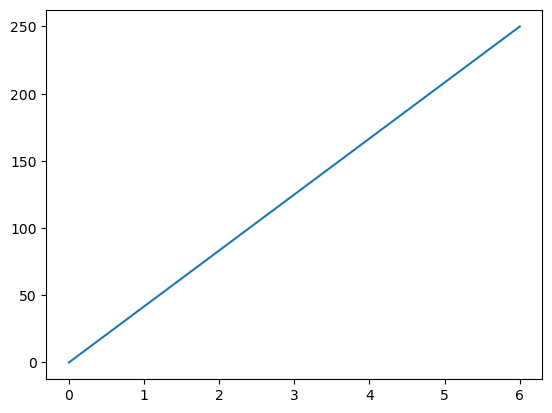

```python
xpoints= np.array([0, 6])
ypoints= np.array([0, 250])
plt.plot(xpoints, ypoints)
plt.show()
```

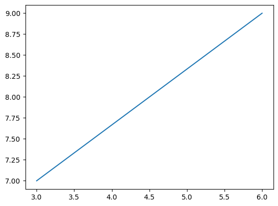

```python
#The plot() function is used to draw points (markers) in a diagram.
x=np.array([3,6])
y=np.array([7,9])
plt.plot(x,y)
plt.show()
```

# Marker

```python
You can use the keyword argument marker to emphasize each point with a specified marker:
```

[figure not shown]

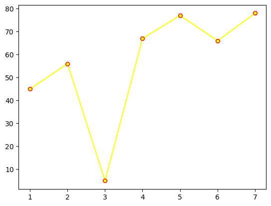

```python
x1=[1,2,3,4,5,6,7]
y2=[30,17,40,45,25,20,20]
plt.plot(x1,y1, marker='H', color='yellow', markeredgecolor='r')
plt.show()
```

# Marker Description

'o' Circle  
'*' Star  
'.' Point  
',' Pixel  
'x' X  
'X' X (filled)  
'+' Plus  
'P' Plus (filled)  
's' Square  
'D' Diamond 'd' Diamond (thin)  
'p' Pentagon  
'H' Hexagon 'h' Hexagon 'v' Triangle Down  
'^' Triangle Up '<' Triangle Left  
'>' Triangle Right  
'1' Tri Down  
'2' Tri Up  
'3' Tri Left  
'4' Tri Right  
'|' Vline  
'_' Hline

# ==================================Line Syntax Description

'-' Solid line  
':' Dotted line '--' Dashed line '-.' Dashed/dotted line

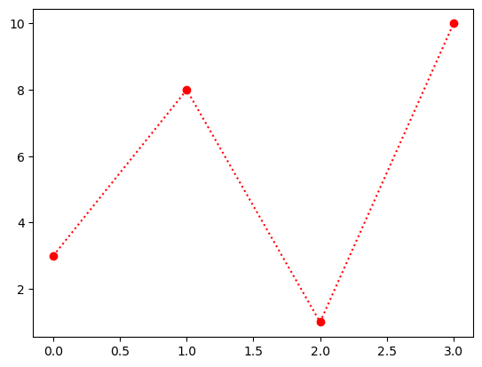

```python
ypoints = np.array([3, 8, 1, 10])

plt.plot(ypoints, 'o:r')
plt.show()
```

# Linestyle

linestyle as ls and it is use to change the style of plotted line. Linechart ls fun=== dotted = : dashed= -- None= no line only marker dashdot=-

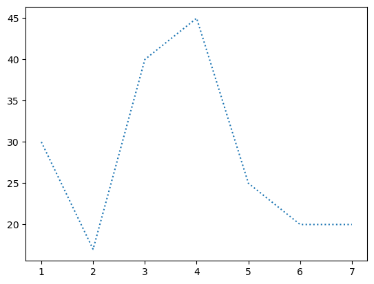

```python
x1=[1,2,3,4,5,6,7]                                         #dotted =:
y2=[30,17,40,45,25,20,20]
plt.plot(x1,y2,linestyle='dotted')
plt.show()
```

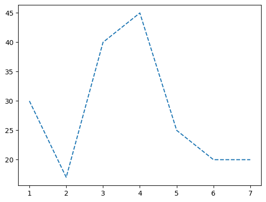

```python
x1=[1,2,3,4,5,6,7]                              #dashed=--
y2=[30,17,40,45,25,20,20]
plt.plot(x1,y2,linestyle='dashed')
plt.show()
```

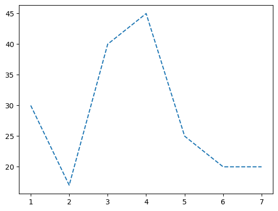

```python
x1=[1,2,3,4,5,6,7]                              #short ls =  --{dashed}
y2=[30,17,40,45,25,20,20]
plt.plot(x1,y2,ls='--')
plt.show()
```

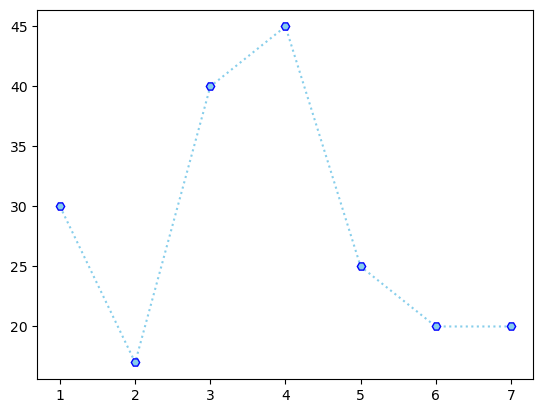

```python
x1=[1,2,3,4,5,6,7]                              #short ls =  --{dotted}
y2=[30,17,40,45,25,20,20]
plt.plot(x1,y2,ls=':', marker='H',color='skyblue',markeredgecolor='Blue')
plt.show()
```

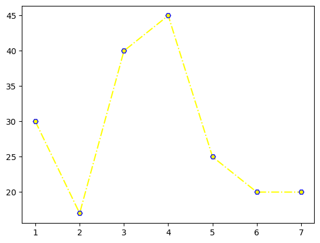

```python
x1=[1,2,3,4,5,6,7]                              #short ls =  --{dashdot= -}
y2=[30,17,40,45,25,20,20]
plt.plot(x1,y2,ls='dashdot', marker='H',color='Yellow',markeredgecolor='Blue')
plt.show()
```

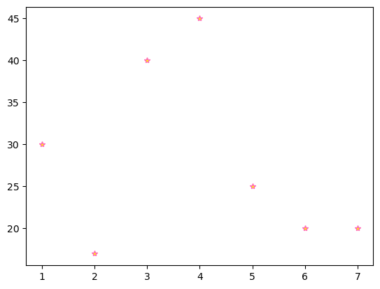

```python
x1=[1,2,3,4,5,6,7]                              #short ls =  --{None=     }
y2=[30,17,40,45,25,20,20]
plt.plot(x1,y2,ls='None', marker='*',color='yellow',markeredgecolor='hotpink')
plt.show()
```

# Line width

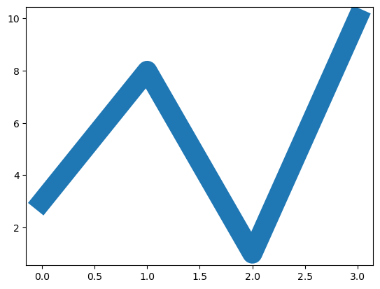

```python
ypoints = np.array([3, 8, 1, 10])

plt.plot(ypoints, linewidth = '20.5')
plt.show()
```

# Multiple lines

Add more lines by simple adding plt.plot

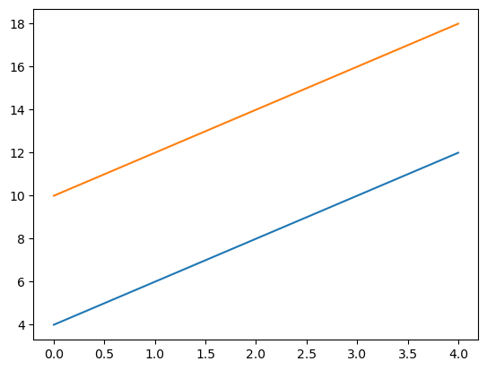

```python
a=[4,6,8,10,12]
b=[10,12,14,16,18]
plt.plot(a)
plt.plot(b)
plt.show()
```

# Lables and title

```python
you can add lables and title in above of the chart and labels can be shown in x axis and y axis places
```

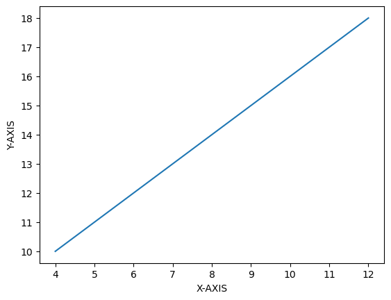

```python
x=[4,6,8,10,12]
y=[10,12,14,16,18]
plt.plot(a,b)
plt.xlabel('X-AXIS')
plt.ylabel('Y-AXIS')
plt.show()
```

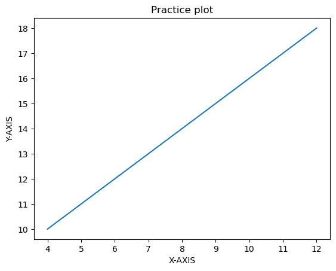

```python
#create a title for plot =title() function to set a title for the plot.

x=[4,6,8,10,12]
y=[10,12,14,16,18]
plt.plot(a,b)

plt.title('Practice plot')
plt.xlabel('X-AXIS')
plt.ylabel('Y-AXIS')
plt.show()
```

# Set Font Properties for Title and Labels FONT

```python
Font= Fondict
```

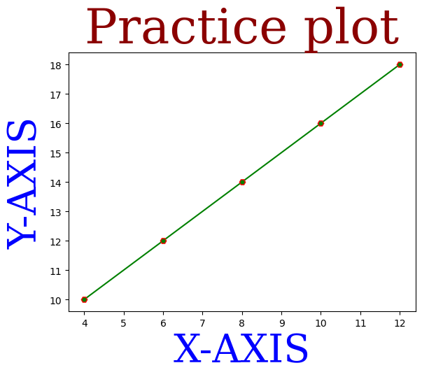

```python
x=[4,6,8,10,12]
y=[10,12,14,16,18]
plt.plot(a,b,marker='H',color='Green',markeredgecolor='red')

font1 = {'family':'serif','color':'blue','size':40}
font2 = {'family':'serif','color':'darkred','size':50}


plt.title('Practice plot', fontdict=font2)
plt.xlabel('X-AXIS', fontdict= font1)
plt.ylabel('Y-AXIS', fontdict=font1)
plt.show()
```

# Loc= to set the position of title in plot

```python
left
right
center=========== center is default
```

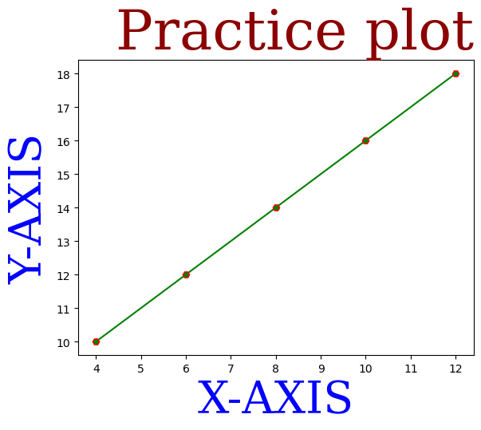

```python
x=[4,6,8,10,12]
y=[10,12,14,16,18]
plt.plot(a,b,marker='H',color='Green',markeredgecolor='red')                          #titlein right side

font1 = {'family':'serif','color':'blue','size':40}
font2 = {'family':'serif','color':'darkred','size':50}


plt.title('Practice plot', fontdict=font2, loc='right')
plt.xlabel('X-AXIS', fontdict= font1)
plt.ylabel('Y-AXIS', fontdict=font1)
plt.show()
```

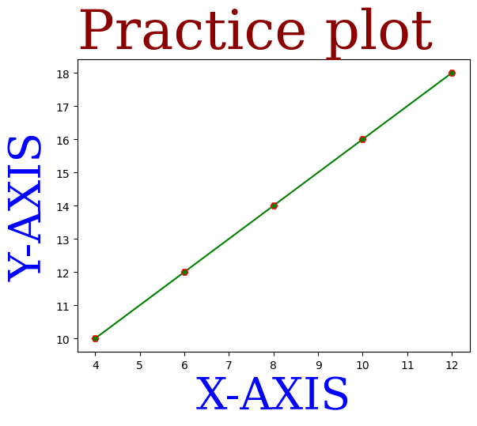

```python
x=[4,6,8,10,12]
y=[10,12,14,16,18]
plt.plot(a,b,marker='H',color='Green',markeredgecolor='red')                          #title in left side

font1 = {'family':'serif','color':'blue','size':40}
font2 = {'family':'serif','color':'darkred','size':50}


plt.title('Practice plot', fontdict=font2, loc='left')
plt.xlabel('X-AXIS', fontdict= font1)
plt.ylabel('Y-AXIS', fontdict=font1)
plt.show()
```

# Add Grid Lines to a Plot

```python
With Pyplot, you can use the grid() function to add grid lines to the plot.
```

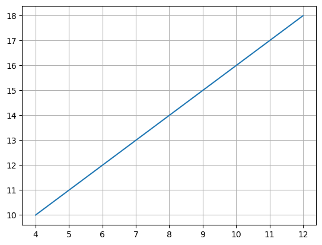

```python
x=[4,6,8,10,12]                             #background grid lines
y=[10,12,14,16,18]
plt.plot(x,y)

plt.grid()
plt.show()
```

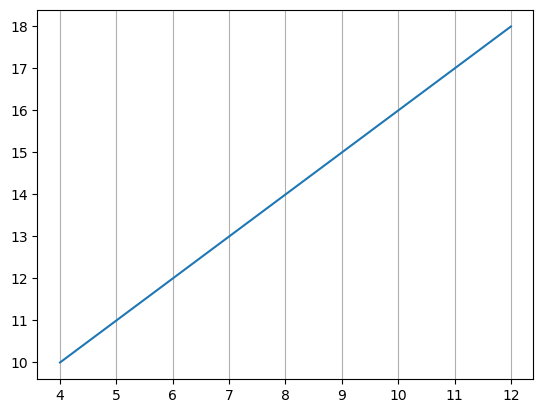

```python
#specific grid lines to be shown
x=[4,6,8,10,12]
y=[10,12,14,16,18]
plt.plot(x,y)

plt.grid(axis= 'x')
plt.show()
```

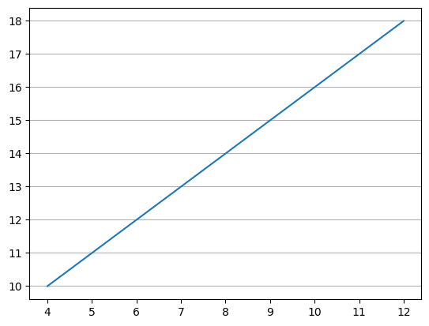

```python
x=[4,6,8,10,12]
y=[10,12,14,16,18]
plt.plot(x,y)

plt.grid(axis= 'y')
plt.show()
```